# Practical Machine Learning Course Project

Surra

March 21, 2015

## Executive Summary

Given both training and test data from the following study:

Velloso, E.; Bulling, A.; Gellersen, H.; Ugulino, W.; Fuks, H. Qualitative Activity Recognition of Weight Lifting Exercises. Proceedings of 4th International Conference in Cooperation with SIGCHI (Augmented Human ’13) . Stuttgart, Germany: ACM SIGCHI, 2013.

the goal of this project is to “predict the manner in which the participants did the exercise.”

THe observation is that Random Forests is a good algorithm to predict how (well) the participants did the exercise.

## Approach

We will take the following approach introduced in the class. Components of a Predictor defines six stages. * Question * Input Data * Features * Algorithm * Parameters * Evaluation

## Question

In the study, six subjects participated in a dumbell lifting exercise five different ways. The five ways as described in the study, were “exactly according to the specification (Class A), throwing the elbows to the front (Class B), lifting the dumbbell only halfway (Class C), lowering the dumbbell only halfway (Class D) and throwing the hips to the front (Class E). Class A corresponds to the specified execution of the exercise, while the other 4 classes correspond to common mistakes.”

One thing that people regularly do is quantify how much of a particular activity they do, but they rarely quantify how well they do it. In this project, your goal will be to use data from accelerometers on the belt, forearm, arm, and dumbell of 6 participants.

The question is to see if the *appropriate activity quality (class A-E) can be predicted?*

## Input Data

We will import the data and verify that the training data and test data are identical.

```r
# Download data.
url_training <- "https://d396qusza40orc.cloudfront.net/predmachlearn/pml-training.csv"
file_training <- "pml-training.csv"
# download.file(url=url_training, destfile=file_training, method="curl")
url_testing <- "https://d396qusza40orc.cloudfront.net/predmachlearn/pml-testing.csv"
file_testing <- "pml-testing.csv"
# download.file(url=url_testing, destfile=file_testing, method="curl")

# Import the data treating empty values as NA.
df_training <- read.csv(file_training, na.strings=c("NA",""), header=TRUE)
colnames_train <- colnames(df_training)
df_testing <- read.csv(file_testing, na.strings=c("NA",""), header=TRUE)
colnames_test <- colnames(df_testing)

# Verify that the column names are identical in the training and test set.
# note that classe and problem_id are different in train and test data sets
all.equal(colnames_train[1:length(colnames_train)-1], colnames_test[1:length(colnames_train)-1])
```

```
## [1] TRUE
```

## Features

Before we figure out the features, it is good to clean the data as: 1. Remove any columns with predominantly NAs 2. Since we are looking at sensor metric data, we can safely drop first 7 columns which are unnecessary for our prediction of interest 3. Apply Level 1: from Raw Data to Covariate – since we have sensor metric data we dont need to perform this step 4. Apply Level 2: Transform tidy covariates after checkign for any variability

```r
# Count the number of non-NAs in each col.
nonNAs <- function(x) {
    as.vector(apply(x, 2, function(x) length(which(!is.na(x)))))
}

# Build vector of NA columns to drop
colcnts <- nonNAs(df_training)
dropCols <- c()
for (cnt in 1:length(colcnts)) {
    if (colcnts[cnt] < nrow(df_training)) {
        dropCols <- c(dropCols, colnames_train[cnt])
    }
}

# Drop NA data and the first 7 columns.
df_training <- df_training[,!(names(df_training) %in% dropCols)]
df_training <- df_training[,8:length(colnames(df_training))]

# Since test data set is the same, do the same on test data
df_testing <- df_testing[,!(names(df_testing) %in% dropCols)]
df_testing <- df_testing[,8:length(colnames(df_testing))]

# Show remaining columns.
# colnames(df_training)
# colnames(df_testing)
```

On to step 4 for applying Level 2 (tidy data to covariates) if necessary. Apply nearZeroVar to check if there is any variability. We can see from below that there is no variability (all near zerio variance variables are FALSE) so nothing to be done at this step.

```r
nsv <- nearZeroVar(df_training, saveMetrics=TRUE)
nsv
```

```
##                      freqRatio percentUnique zeroVar   nzv
## roll_belt             1.101904     6.7781062   FALSE FALSE
## pitch_belt            1.036082     9.3772296   FALSE FALSE
## yaw_belt              1.058480     9.9734991   FALSE FALSE
## total_accel_belt      1.063160     0.1477933   FALSE FALSE
## gyros_belt_x          1.058651     0.7134849   FALSE FALSE
## gyros_belt_y          1.144000     0.3516461   FALSE FALSE
## gyros_belt_z          1.066214     0.8612782   FALSE FALSE
## accel_belt_x          1.055412     0.8357966   FALSE FALSE
## accel_belt_y          1.113725     0.7287738   FALSE FALSE
## accel_belt_z          1.078767     1.5237998   FALSE FALSE
## magnet_belt_x         1.090141     1.6664968   FALSE FALSE
## magnet_belt_y         1.099688     1.5187035   FALSE FALSE
## magnet_belt_z         1.006369     2.3290184   FALSE FALSE
## roll_arm             52.338462    13.5256345   FALSE FALSE
## pitch_arm            87.256410    15.7323412   FALSE FALSE
## yaw_arm              33.029126    14.6570176   FALSE FALSE
## total_accel_arm       1.024526     0.3363572   FALSE FALSE
## gyros_arm_x           1.015504     3.2769341   FALSE FALSE
## gyros_arm_y           1.454369     1.9162165   FALSE FALSE
## gyros_arm_z           1.110687     1.2638875   FALSE FALSE
## accel_arm_x           1.017341     3.9598410   FALSE FALSE
## accel_arm_y           1.140187     2.7367241   FALSE FALSE
## accel_arm_z           1.128000     4.0362858   FALSE FALSE
## magnet_arm_x          1.000000     6.8239731   FALSE FALSE
## magnet_arm_y          1.056818     4.4439914   FALSE FALSE
## magnet_arm_z          1.036364     6.4468454   FALSE FALSE
## roll_dumbbell         1.022388    84.2065029   FALSE FALSE
## pitch_dumbbell        2.277372    81.7449801   FALSE FALSE
## yaw_dumbbell          1.132231    83.4828254   FALSE FALSE
## total_accel_dumbbell  1.072634     0.2191418   FALSE FALSE
## gyros_dumbbell_x      1.003268     1.2282132   FALSE FALSE
## gyros_dumbbell_y      1.264957     1.4167771   FALSE FALSE
## gyros_dumbbell_z      1.060100     1.0498420   FALSE FALSE
## accel_dumbbell_x      1.018018     2.1659362   FALSE FALSE
## accel_dumbbell_y      1.053061     2.3748853   FALSE FALSE
## accel_dumbbell_z      1.133333     2.0894914   FALSE FALSE
## magnet_dumbbell_x     1.098266     5.7486495   FALSE FALSE
## magnet_dumbbell_y     1.197740     4.3012945   FALSE FALSE
## magnet_dumbbell_z     1.020833     3.4451126   FALSE FALSE
## roll_forearm         11.589286    11.0895933   FALSE FALSE
## pitch_forearm        65.983051    14.8557741   FALSE FALSE
## yaw_forearm          15.322835    10.1467740   FALSE FALSE
## total_accel_forearm   1.128928     0.3567424   FALSE FALSE
## gyros_forearm_x       1.059273     1.5187035   FALSE FALSE
## gyros_forearm_y       1.036554     3.7763735   FALSE FALSE
## gyros_forearm_z       1.122917     1.5645704   FALSE FALSE
## accel_forearm_x       1.126437     4.0464784   FALSE FALSE
## accel_forearm_y       1.059406     5.1116094   FALSE FALSE
## accel_forearm_z       1.006250     2.9558659   FALSE FALSE
## magnet_forearm_x      1.012346     7.7667924   FALSE FALSE
## magnet_forearm_y      1.246914     9.5403119   FALSE FALSE
## magnet_forearm_z      1.000000     8.5771073   FALSE FALSE
## classe                1.469581     0.0254816   FALSE FALSE
```

## Algorithm

```r
set.seed(345)
index_subset <- createDataPartition(y=df_training$classe, p=0.75, list=FALSE)
df_ss_train <- df_training[index_subset,]
df_ss_valid <- df_training[-index_subset,]
```

Based on the paper published on this study and course lectures/discussions, we are going to try two different algorithms via caret package: classification tree (method=rpart) and random forests.

## Parameters

The variable “classe” contains 5 levels: A, B, C, D and E. A plot of the outcome variable will allow us to see the frequency of each levels in the subTraining data set and compare one another.

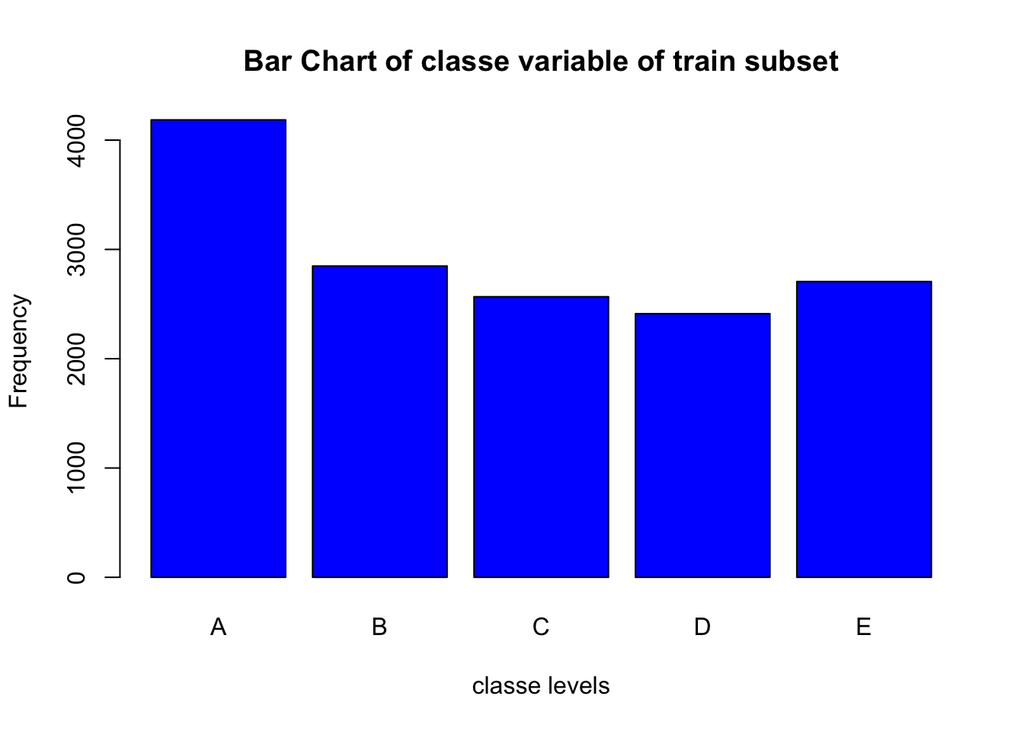

```r
plot(df_ss_train$classe, col="blue", main="Bar Chart of classe variable of train subset", xlab="classe levels", ylab="Frequency")
```

Each level frequency is in about the same order of magnitude.

## Evaluation

**Classification Tree**

Let us apply classification tree on the training subset.

```r
set.seed(345)
modFit <- train(df_ss_train$classe ~ ., data = df_ss_train, method="rpart")
print(modFit, digits=3)
```

```
## CART
##
## 14718 samples
##    52 predictor
##     5 classes: 'A', 'B', 'C', 'D', 'E'
##
## No pre-processing
## Resampling: Bootstrapped (25 reps)
##
## Summary of sample sizes: 14718, 14718, 14718, 14718, 14718, 14718, ...
##
## Resampling results across tuning parameters:
##
##   cp      Accuracy  Kappa   Accuracy SD  Kappa SD
##   0.0338  0.519     0.3740  0.0388       0.0624
##   0.0608  0.396     0.1757  0.0563       0.0933
##   0.1160  0.325     0.0638  0.0416       0.0626
##
## Accuracy was used to select the optimal model using  the largest value.
## The final value used for the model was cp = 0.0338.
```

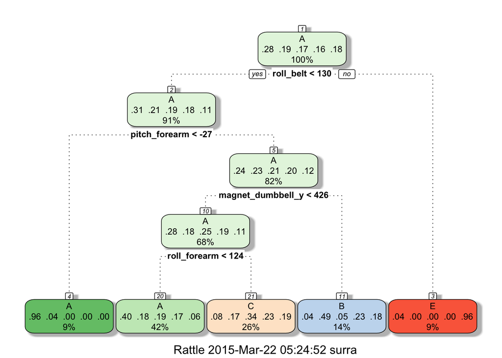

```r
fancyRpartPlot(modFit$finalModel)
```

Run predictions against validation subset

```r
# run predictions against validation subset
predicts <- predict(modFit, newdata=df_ss_valid)
print(confusionMatrix(predicts, df_ss_valid$classe), digits=4)
```

```
## Confusion Matrix and Statistics
##
##           Reference
## Prediction    A    B    C    D    E
##          A 1258  399  402  357  132
##          B   28  325   34  140  119
##          C   87  225  419  307  225
##          D    0    0    0    0    0
##          E   22    0    0    0  425
##
## Overall Statistics
##
##                Accuracy : 0.4949
##                  95% CI : (0.4808, 0.509)
##     No Information Rate : 0.2845
##     P-Value [Acc > NIR] : < 2.2e-16
##
##                   Kappa : 0.3398
##  Mcnemar's Test P-Value : NA
##
## Statistics by Class:
##
##                      Class: A Class: B Class: C Class: D Class: E
## Sensitivity            0.9018  0.34247  0.49006   0.0000  0.47170
## Specificity            0.6324  0.91884  0.79155   1.0000  0.99450
## Pos Pred Value         0.4937  0.50310  0.33175      NaN  0.95078
## Neg Pred Value         0.9419  0.85345  0.88025   0.8361  0.89320
## Prevalence             0.2845  0.19352  0.17435   0.1639  0.18373
## Detection Rate         0.2565  0.06627  0.08544   0.0000  0.08666
## Detection Prevalence   0.5196  0.13173  0.25754   0.0000  0.09115
## Balanced Accuracy      0.7671  0.63065  0.64081   0.5000  0.73310
```

That shows a very low accuracy of 0.4949. let us see if this improves with pre-processing and cross validation.

```r
set.seed(345)
modFit <- train(df_ss_train$classe ~ .,  preProcess=c("center", "scale"), trControl=trainControl(method = "cv", number = 4), data = df_ss_train, method="rpart")
print(modFit, digits=3)
```

```
## CART
##
## 14718 samples
##    52 predictor
##     5 classes: 'A', 'B', 'C', 'D', 'E'
##
## Pre-processing: centered, scaled
## Resampling: Cross-Validated (4 fold)
##
## Summary of sample sizes: 11037, 11040, 11039, 11038
##
## Resampling results across tuning parameters:
##
##   cp      Accuracy  Kappa   Accuracy SD  Kappa SD
##   0.0338  0.519     0.3774  0.0201       0.0375
##   0.0608  0.397     0.1760  0.0631       0.1060
##   0.1160  0.304     0.0301  0.0393       0.0603
##
## Accuracy was used to select the optimal model using  the largest value.
## The final value used for the model was cp = 0.0338.
```

Run predictions against the validation subset

```r
predicts <- predict(modFit, newdata=df_ss_valid)
print(confusionMatrix(predicts, df_ss_valid$classe), digits=4)
```

```
## Confusion Matrix and Statistics
##
##           Reference
## Prediction    A    B    C    D    E
##          A 1258  399  402  357  132
##          B   28  325   34  140  119
##          C   87  225  419  307  225
##          D    0    0    0    0    0
##          E   22    0    0    0  425
##
## Overall Statistics
##
##                Accuracy : 0.4949
##                  95% CI : (0.4808, 0.509)
##     No Information Rate : 0.2845
##     P-Value [Acc > NIR] : < 2.2e-16
##
##                   Kappa : 0.3398
##  Mcnemar's Test P-Value : NA
##
## Statistics by Class:
##
##                      Class: A Class: B Class: C Class: D Class: E
## Sensitivity            0.9018  0.34247  0.49006   0.0000  0.47170
## Specificity            0.6324  0.91884  0.79155   1.0000  0.99450
## Pos Pred Value         0.4937  0.50310  0.33175      NaN  0.95078
## Neg Pred Value         0.9419  0.85345  0.88025   0.8361  0.89320
## Prevalence             0.2845  0.19352  0.17435   0.1639  0.18373
## Detection Rate         0.2565  0.06627  0.08544   0.0000  0.08666
## Detection Prevalence   0.5196  0.13173  0.25754   0.0000  0.09115
## Balanced Accuracy      0.7671  0.63065  0.64081   0.5000  0.73310
```

That did not change the accuracy – so abandoning this algorithm and trying out Random Forests

**NOTE:** The computer is hanging with the large training data set, so running the random forest algorithms on a much smaller data set.

```r
index_subset1 <- createDataPartition(y=df_training$classe, p=0.25, list=FALSE)
df_ss_train <- df_training[index_subset1,]
```

```r
set.seed(345)
# modFit <- train(df_ss_train$classe ~ ., method="rf", data=df_ss_train)
# print(modFit, digits=3)
```

Run predictions against the validation subset of training data.

```r
# predicts <- predict(modFit, newdata=df_ss_valid)
# print(confusionMatrix(predicts, df_ss_valid$classe), digits=4)
```

Check the random forest with pre-processing and cross validation

```r
set.seed(345)
modFit <- train(df_ss_train$classe ~ ., method="rf", preProcess=c("center", "scale"), trControl=trainControl(method = "cv", number = 4), data=df_ss_train)
print(modFit, digits=3)
```

```
## Random Forest
##
## 4907 samples
##   52 predictor
##    5 classes: 'A', 'B', 'C', 'D', 'E'
##
## Pre-processing: centered, scaled
## Resampling: Cross-Validated (4 fold)
##
## Summary of sample sizes: 3680, 3681, 3680, 3680
##
## Resampling results across tuning parameters:
##
##   mtry  Accuracy  Kappa  Accuracy SD  Kappa SD
##    2    0.966     0.957  0.00512      0.00648
##   27    0.967     0.958  0.00403      0.00509
##   52    0.961     0.951  0.00723      0.00915
##
## Accuracy was used to select the optimal model using  the largest value.
## The final value used for the model was mtry = 27.
```

Run predictions against the validation subset of training data.

```r
predicts <- predict(modFit, newdata=df_ss_valid)
print(confusionMatrix(predicts, df_ss_valid$classe), digits=4)
```

```
## Confusion Matrix and Statistics
##
##           Reference
## Prediction    A    B    C    D    E
##          A 1392   15    0    0    0
##          B    1  923   12    0    1
##          C    1   11  833   15    1
##          D    0    0    9  786    4
##          E    1    0    1    3  895
##
## Overall Statistics
##
##                Accuracy : 0.9847
##                  95% CI : (0.9809, 0.988)
##     No Information Rate : 0.2845
##     P-Value [Acc > NIR] : < 2.2e-16
##
##                   Kappa : 0.9807
##  Mcnemar's Test P-Value : NA
##
## Statistics by Class:
##
##                      Class: A Class: B Class: C Class: D Class: E
## Sensitivity            0.9978   0.9726   0.9743   0.9776   0.9933
## Specificity            0.9957   0.9965   0.9931   0.9968   0.9988
## Pos Pred Value         0.9893   0.9851   0.9675   0.9837   0.9944
## Neg Pred Value         0.9991   0.9934   0.9946   0.9956   0.9985
## Prevalence             0.2845   0.1935   0.1743   0.1639   0.1837
## Detection Rate         0.2838   0.1882   0.1699   0.1603   0.1825
## Detection Prevalence   0.2869   0.1911   0.1756   0.1629   0.1835
## Balanced Accuracy      0.9968   0.9845   0.9837   0.9872   0.9960
```

```r
# Run against 20 testing set provided by Professor Leek.
print(predict(modFit, newdata=df_testing))
```

```
##  [1] B A A A A E D B A A B C B A E E A B B B
## Levels: A B C D E
```

## Conclusion:

We applied different models but chose RF with preprocessign and cross validation.

Due to hang of my machine I am not able to complete the last comparison (even with a smaller training set) of RF algorithms.